# Lab 06: Intro to Inference, Confidence Intervals, Resampling, and Significance

Mandy Klehr — I worked with Matt, Jahiya, John, and Bonnie

10/24/2021

# Q1

I found this one difficult, only because I tried to use the *!is.na()* in the function with the length of x for the sample size, but I kept getting a value that was not the same 43.36473 for body mass of the penguins data. Instead it was 43.23849 which seems to indicate that it is not excluding the *NA*s in the dataframe. So I did some searching and found the *na.omit()* command that seemed to work. I am not sure this is as powerful as using the *!* and *is.na()*, but it worked for me in this exercise and in lab 7.

```r
rm(list = ls())

sse_mean = function(x)
{
  sse = sd(x, na.rm = TRUE) / sqrt(length(na.omit(x)))
  return(sse)
}

require(palmerpenguins)

sse_mean(penguins$body_mass_g)
```

```
## [1] 43.36473
```

```r
sse_mean(mtcars$mpg)
```

```
## [1] 1.065424
```

# Q2

```r
dat_pen = droplevels(subset(penguins, species != "Gentoo"))

x = dat_pen$flipper_length_mm
n_1 = 68
n_2 = 152

two_group_resample = function(x, n_1, n_2)
{
  dat_1 = sample(x, n_1, replace = TRUE)
  dat_2 = sample(x, n_2, replace = TRUE)

  difference_in_means =
    mean(dat_1, na.rm = TRUE) - mean(dat_2, na.rm = TRUE)

  return(difference_in_means)
}
```

# Q3

Monte Carlo because this resampling and shuffling all values by removing any association to the species within the penguin data, thus it is simulating a null hypothesis in that there is no difference in flipper length between the two species.

# Q4

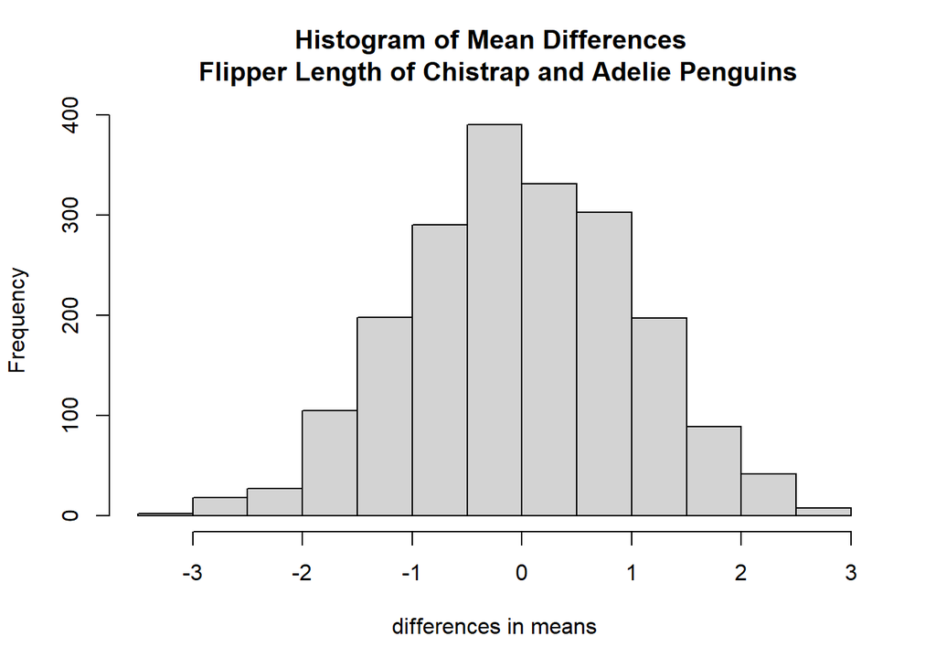

```r
n = 2000
mean_differences = c()
for (i in 1:n)
{
  mean_differences = c(
    mean_differences,
    two_group_resample(dat_pen$flipper_length_mm, 68, 152))
}

hist(mean_differences,
     main = "Histogram of Mean Differences \n Flipper Length of Chistrap and Adelie Penguins",
     xlab = "differences in means")
```

# Q5

None of the resampled difference of means were greater than 5.8

```r
sum(abs(mean_differences > 5.8))
```

```
## [1] 0
```

```r
#or

t_test = t.test(dat_pen$flipper_length_mm ~ dat_pen$species)
diff_observed = round(diff(t_test$estimate), digits = 3)
sum(abs(mean_differences > diff_observed))
```

```
## [1] 0
```

# Q6

At least more than 10,000,000, any less than that, there would be a slim chance that the mean would be greater than 5.8. Increasing the number of simulations beyond 10,000,000 will increase the chance that the mean would be greater than 5.8.

# Resampling a different variable

## Code for aggregate

```r
# use aggregate to calculate group means and difference in means

agg_means = aggregate(
  bill_length_mm ~ species,
  data = dat_pen,
  FUN = mean,
  na.rm = TRUE)
diff_crit = diff(agg_means[, 2])

agg_means
```

```
##     species bill_length_mm
## 1    Adelie       38.79139
## 2 Chinstrap       48.83382
```

```r
diff_crit
```

```
## [1] 10.04243
```

## Code for t-test

```r
# Conduct a t-test and observe the p-value

t_test_bill = t.test(dat_pen$bill_length_mm ~ dat_pen$species)
t_test_bill
```

```
##
##  Welch Two Sample t-test
##
## data:  dat_pen$bill_length_mm by dat_pen$species
## t = -21.865, df = 106.97, p-value < 2.2e-16
## alternative hypothesis: true difference in means between group Adelie and group Chinstrap is not equal to 0
## 95 percent confidence interval:
##  -10.952948  -9.131917
## sample estimates:
##    mean in group Adelie mean in group Chinstrap
##                38.79139                48.83382
```

## Code for resampling

```r
#resampling test with 1000 repetitions using two_group_resample
n = 1000
mean_differences_bill = c()
for (i in 1:n)
{
  mean_differences_bill = c(
    mean_differences_bill,
    two_group_resample(dat_pen$bill_length_mm, 68, 152))
}
```

# Q7

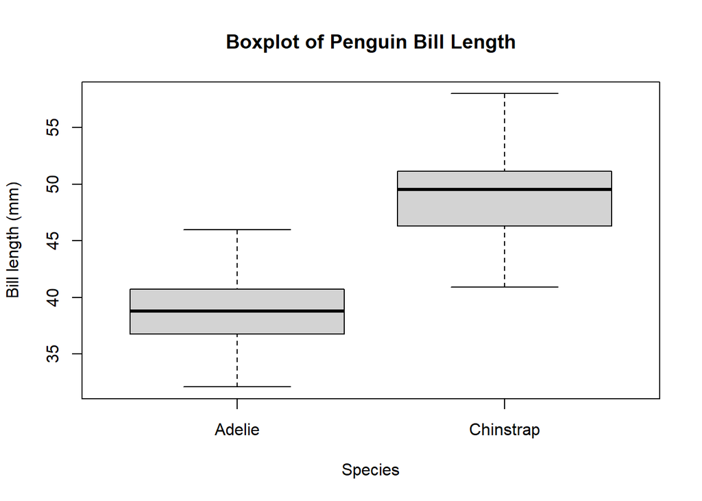

```r
boxplot(bill_length_mm ~ species, data = dat_pen,
        main = "Boxplot of Penguin Bill Length",
        xlab = "Species", ylab = "Bill length (mm)")
```

# Q8

Group means for the two species are: chinstrap = 48.83382 and adelie = 38.79139. The difference between means is 10.04243.

# Q9

If we were to test a hypothesis that there is no difference in bill length between chinstrap and adelie penguins, e.g., the null hypothesis, and an alternative hypothesis is that there is a difference in bill length between these two species, we can look at the p-value of samples of these measurements. Our p-value is less than 2.2e-16; this is a very, very, very small value. Therefore, with this p-value we can reject the null hypothesis and surmise that it is likely that there is a difference in bill length between the chinstrap and adelie penguins based on our samples.

# Q10

0

```r
sum(abs(mean_differences_bill > diff_crit))
```

```
## [1] 0
```

# Q11

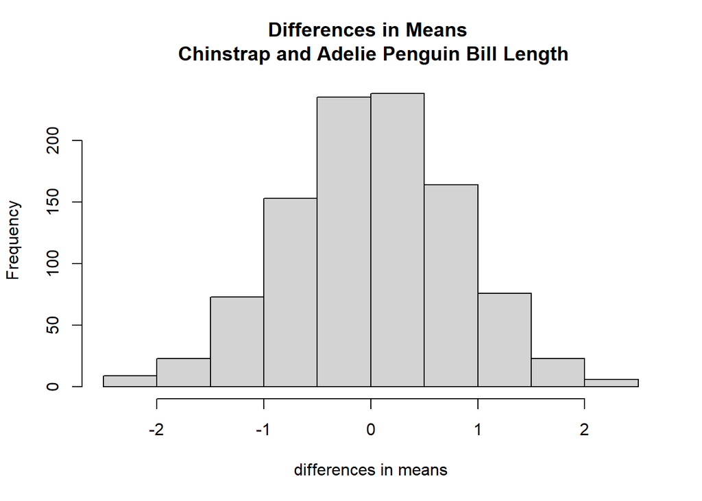

```r
hist(mean_differences_bill,
     main = "Differences in Means \n Chinstrap and Adelie Penguin Bill Length",
     xlab = "differences in means")
```